# Analysis of Preprocessing Results

Anthony Barente

11/18/2021

## 1. Intro:

The two major effects that we need to address in this data are the missingness and batch effects. We turned to the QRILC algorithm for imputation, given the left censoring apparent in the last notebook. For batch correction, we used Combat, and produced a final imputated and batch corrected dataset. However, for differential expression, it is important that the uncorrected data is used. Thus, both datasets are provided as detailed bellow.

## 2. Data Used:

Meta data for this report are available in:

- `yeast_phospho_data_processed/site_data_v2/meta_runs_samples.csv`

Orginal data without imputation can be found in:

- `yeast_phospho_data_processed/site_data_v2/data_psites.vfilt.50.csv`

Uncorrected imputed data can be found in:

- `yeast_phospho_data_processed/site_data_v2/imputation/data_psites.vfilt.50.qrilc.rep1.csv`

Corrected and imputed data can be found in:

- `yeast_phospho_data_processed/site_data_v2/batch_correction/data_psites.vfilt.50.qrilc.rep1.corrected.csv`

## 3. Effect of imputation on data

The QRILC algorithm is specifically designed to impute data with low intensity values. It does this by assuming that all data which is missing came from the lower tail of a truncated normal. This is a hard assumption since often the data can be missing and still have quite high quant.

#### 3.1 Total amount of imputed data

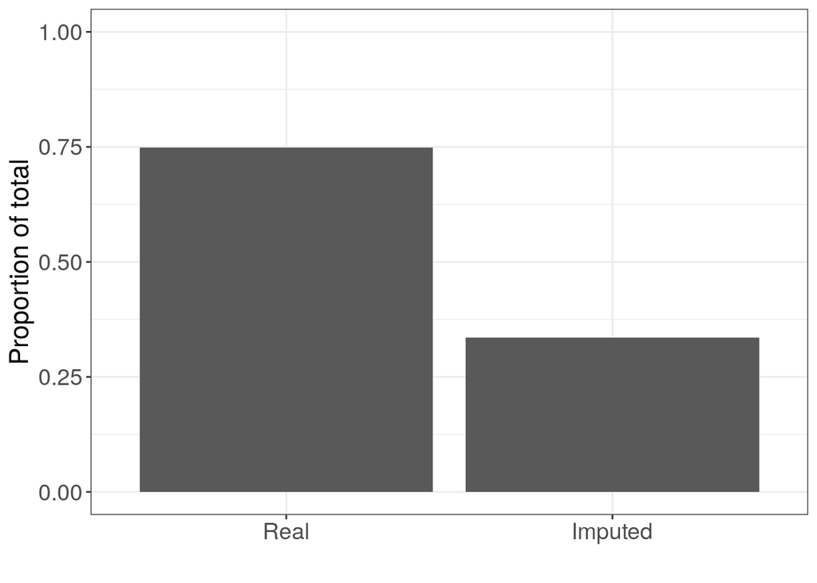

Previously we decided on a cutoff of 50% missingness for the data. This results in a little over 30% missinness on the full data set.

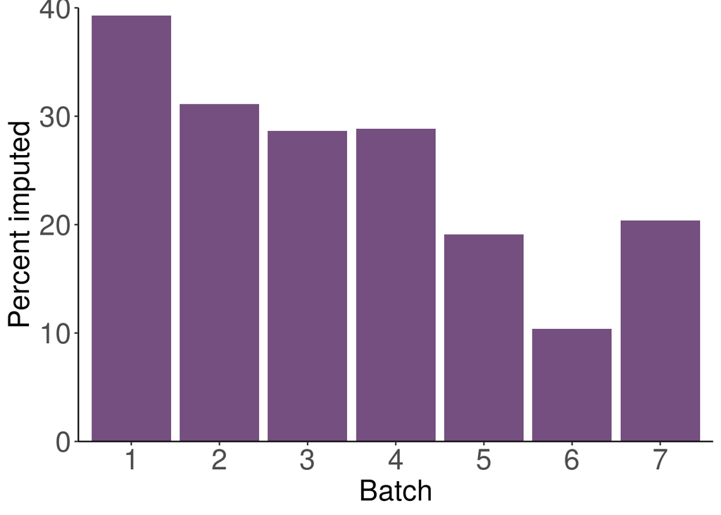

As expected though, this missingness is not evenly distributed accross batches. In some batches, where we have the deepest coverage, we see low missingness. It is unclear what kind of effect this will have on the final data.

#### 3.2 Distribution of imputed data

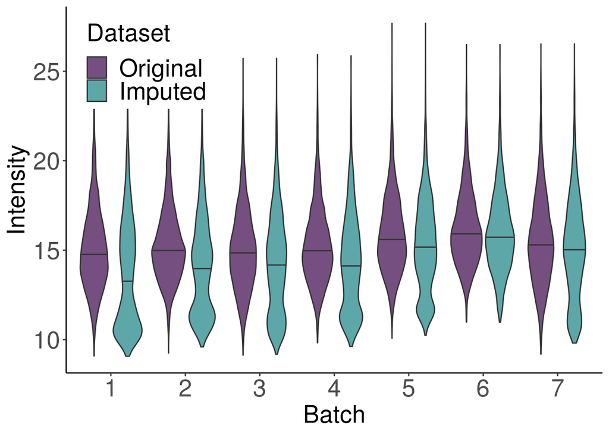

I think the effect of the QRILC algorithm is quit clear in the data above. The addition of a large mode at the bottom of the distributions gives an indication where most of the imputed values lie. For some of the data, this looks fine, but it may be somewhat skewed for certain batches.

## 4. Removal of batch effects

Combat is a standard program for batch correction and should work fine to remove most of the effect. This dataset will be provided as is for many of the analyses which need corrected data to work. For things like differential expression, we will use SVA to analyze the data, which avoids some pitfalls with doing t-tests on corrected data.

#### 4.1 Batch effects in the imputed data

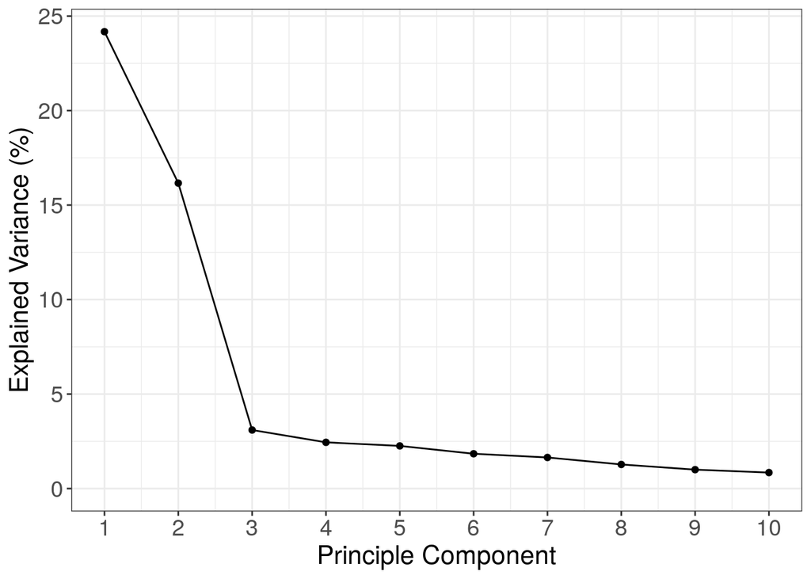

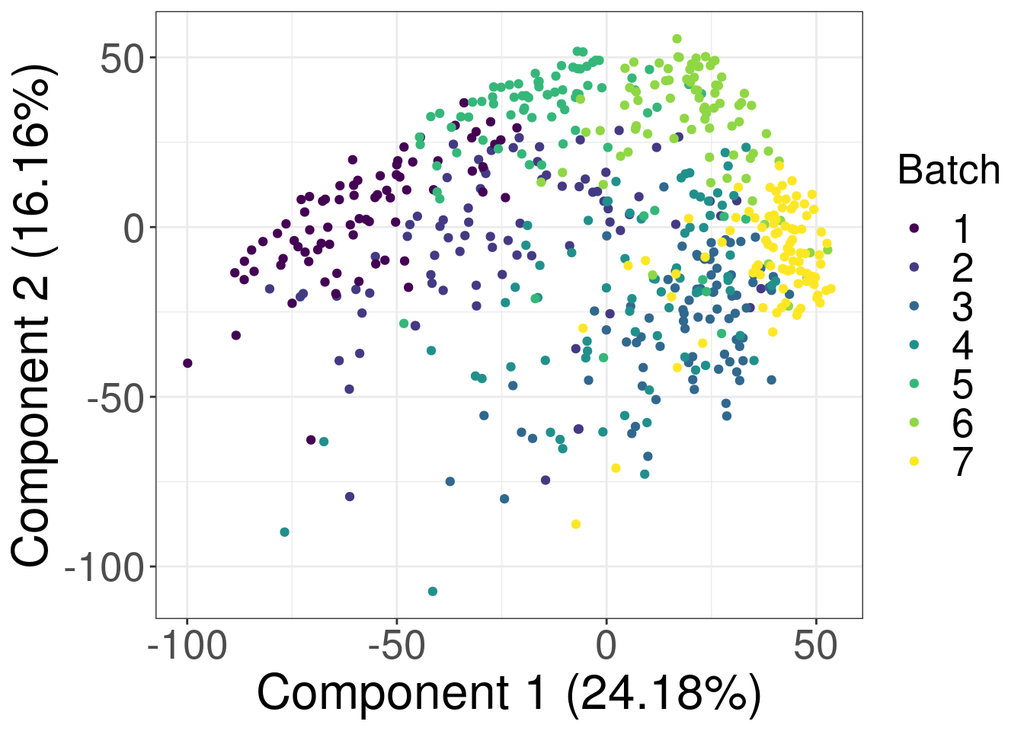

The above PCA gives a clear look at the batch effects in the data.

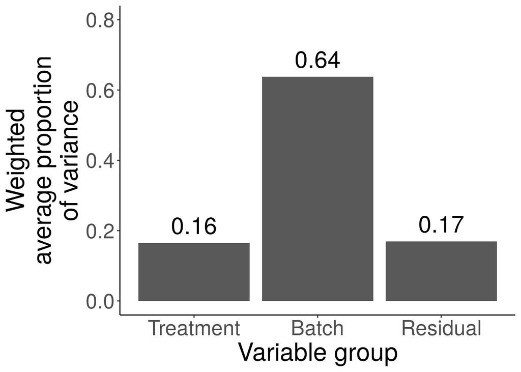

For a more quantified look, I also provide a PVCA analysis above, which indicates a majority of the variance can be explained with the batch variable. In this case the batch variance encompases both the batch and within batch blocks.

#### 4.2 Overview of corrected data

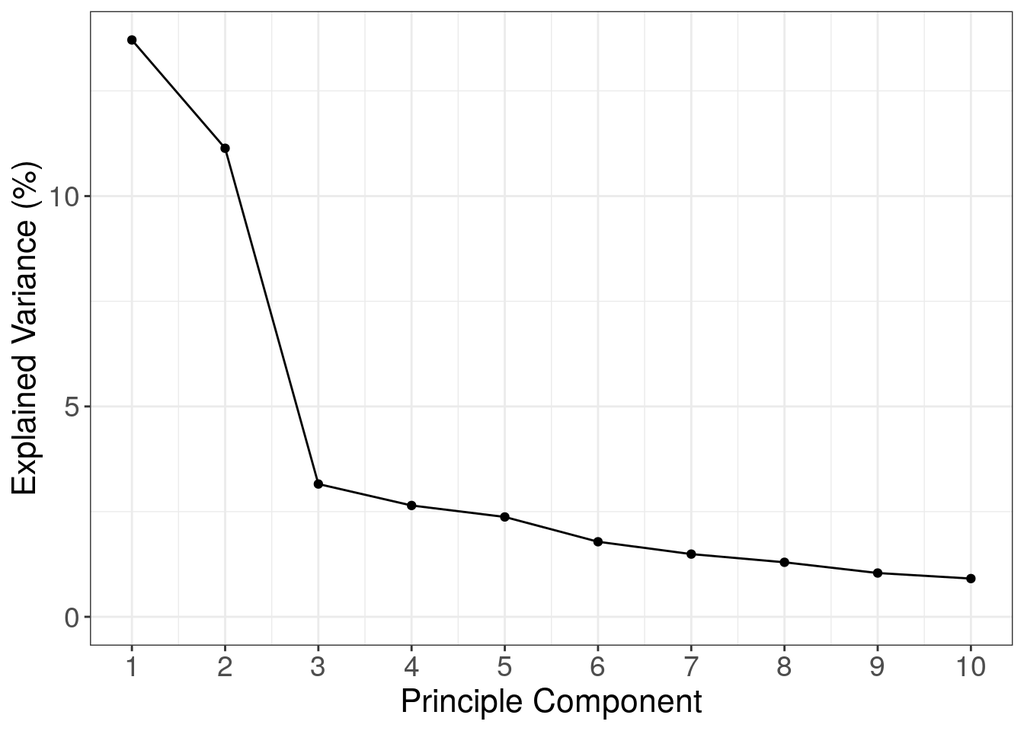

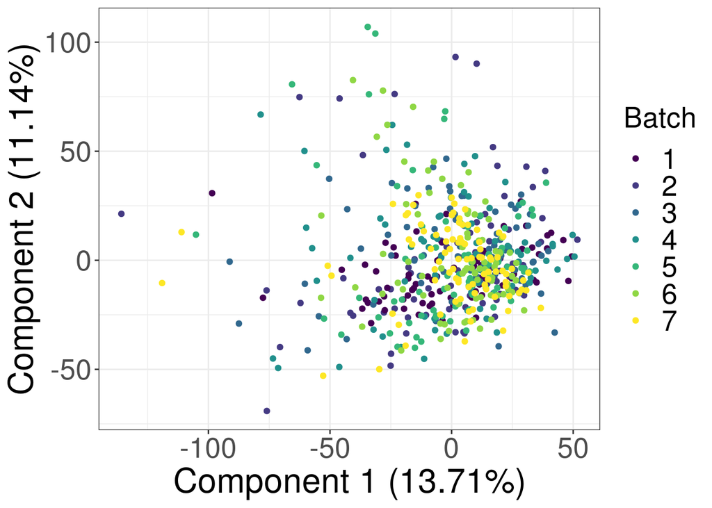

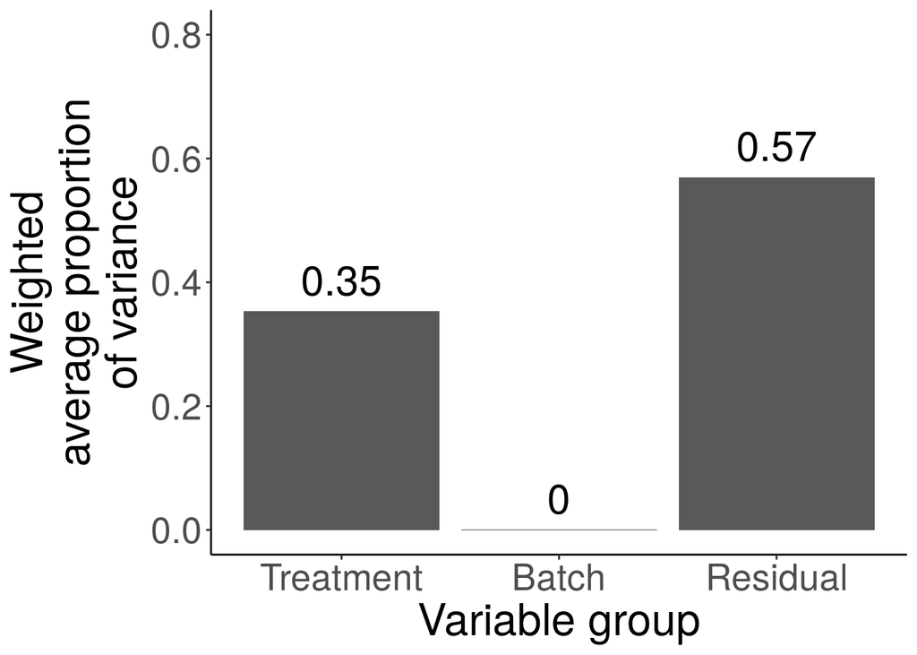

#### 5.1 Comparing median correlation between imputed and corrected data

```
## # A tibble: 1 × 1
##   `median((medCorCorrected - medCorImputed)/medCorImputed)`
##                                                       <dbl>
## 1                                                     0.308
```

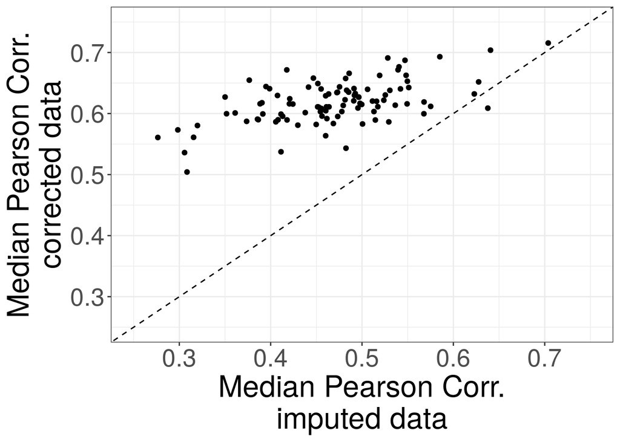

```
## # A tibble: 1 × 1
##   `median(improvement)`
##                   <dbl>
## 1                  30.8
```

#### 5.2 Comparing CVs between imputed and corrected data

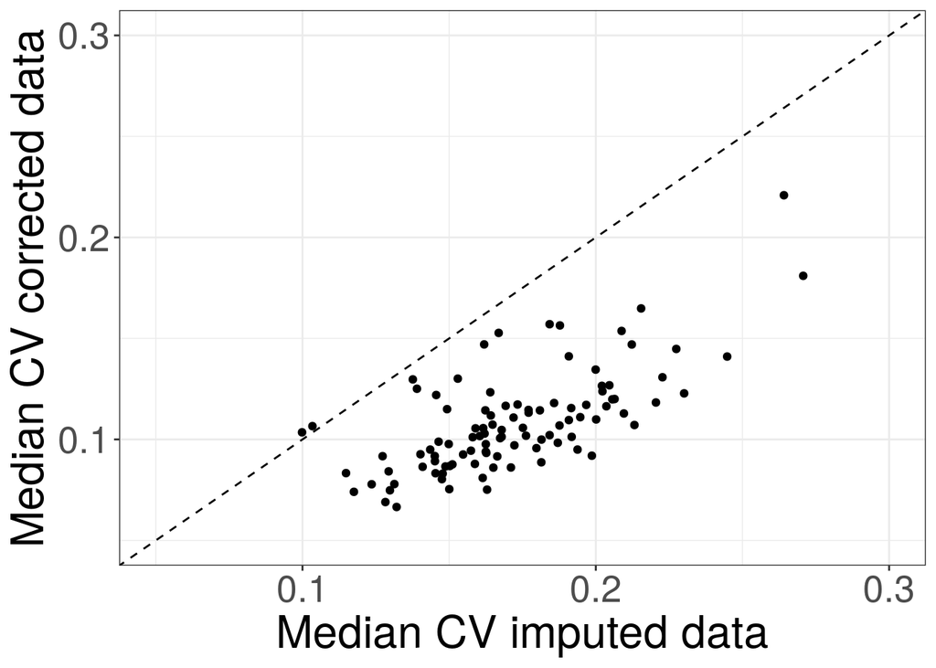

```
## # A tibble: 1 × 1
##   `median(improvement)`
##                   <dbl>
## 1                 -38.8
```